# Mapping FBI Crime Data Reporting Across the U.S.

Proposal

This project will explore patterns in FBI crime reporting participation using the TidyTuesday dataset on agency participation in the National Incident-Based Reporting System (NIBRS).

Author

Affiliation

Ashton Norman

College of Engineering, University of Arizona

## Dataset

```
# A tibble: 6 × 10
  ori       county latitude longitude state_abbr state   agency_name agency_type
  <chr>     <chr>     <dbl>     <dbl> <chr>      <chr>   <chr>       <chr>
1 AL0430200 LEE        32.6     -85.4 AL         Alabama Opelika Po… City
2 AL0430100 LEE        32.6     -85.5 AL         Alabama Auburn Pol… City
3 AL0430000 LEE        32.6     -85.4 AL         Alabama Lee County… County
4 AL0070100 BIBB       33.0     -87.1 AL         Alabama Centrevill… City
5 AL0070000 BIBB       32.9     -87.1 AL         Alabama Bibb Count… County
6 AL0070300 BIBB       33.0     -87.1 AL         Alabama West Bloct… City
# ℹ 2 more variables: is_nibrs <lgl>, nibrs_start_date <date>
```

This dataset was sourced from the [FBI’s Crime Data API](https://cde.ucr.cjis.gov/LATEST/webapp/#/pages/docApi) and curated by [Ford Johnson](https://github.com/bradfordjohnson) for the [TidyTuesday project on February 18, 2025](https://github.com/rfordatascience/tidytuesday/tree/main/data/2025/2025-02-18). The data includes law enforcement participation in the National Incident-Based Reporting System (NIBRS), agency names, type (county/city), geographic location, and reporting start date.

#### Dataset Overview

Dataset Overview

| Variables | Notes |
| --- | --- |
| County | Number of counties included: 2372 |
| State | Number of states included: 50 |
| Agency Type | City, County, University or College, Other, Other State Agency, Tribal, State Police, Unknown |
| Agency (ORI) | Number of agencies included: 19166 |
| Reporting | Percentage of agencies reporting: 79% |
| Start Date | Date Range: 1985-01-01 to 2024-03-01 |

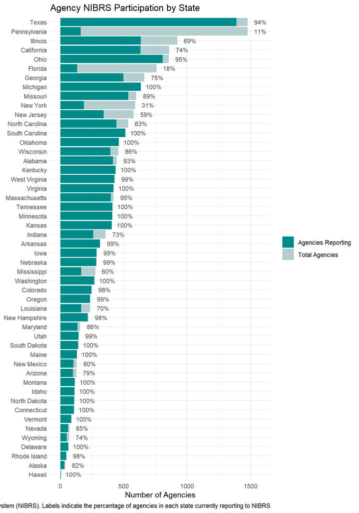

I selected this dataset because it includes geographic variables such as `longitude`, `latitude`, `state`, and `county` that can be used for location-specific and state-level map visualizations. Participating agencies also have a `start_date`, which will allow for visualizations of timelines and pattern changes. My work involves research on infectious diseases, so improving my skills in these areas would be useful for communicating information such as outbreak data trends.

## Questions

1. Which U.S. states and regions have lower levels of NIBRS adoption by law enforcement agencies, and are there patterns by geography or agency type?
   1. Hypothesis: States with a mix of large cities and rural areas will have lower NIBRS participation due to variation in agency structure and likelihood of having a large number of total agencies.
2. How has NIBRS participation expanded geographically from 1985 to 2024?
   1. Hypothesis: NIBRS adoption has increased more rapidly in the last decade due to advancements in technology and broader adoption of centralized and streamlined data collection and reporting systems. I expect states with smaller populations to have higher adoption rates earlier, while more populous states will lag behind.

## Analysis plan

- Question 1: Current participation levels have been explored above at the state level and graphed on the bar chart titled *Agency Participation by State,* which compares total and number of participating agencies within states and includes the percentage reporting to NIBRS as labels. I plan to build on this to further explore patterns and trends by agency type and region (Northeast, Midwest, South, and West).
  - Quantitative Methods: Calculate proportion of participating agencies (`report_status==TRUE`) within each `region` and by `agency_type`, if time permits, significance tests may be explored.
  - Visual Methods: Bar or dot plots for side-by-side comparisons - other options for visual comparison may be explored as well.
  - Variables:
    - `state`: to summarize participation by state and region
    - `county`: to potentially be used for a more detailed look at specific areas within states or across certain regions
    - `agency_type`: for comparing participation across agency types
    - `report_status`: variable for determining participation status
    - `region`: states grouped to 4 US Census regions based on definitions referenced from the [CDC](https://www.cdc.gov/nchs/hus/sources-definitions/geographic-region.htm) website. Full list and map of states by region included below:

U.S. Regions

| Region | States |
| --- | --- |
| Northeast | Connecticut, Maine, Massachusetts, New Hampshire, New Jersey, New York, Pennsylvania, Rhode Island, Vermont |
| Midwest | Illinois, Indiana, Iowa, Kansas, Michigan, Minnesota, Missouri, Nebraska, North Dakota, Ohio, South Dakota, Wisconsin |
| South | Alabama, Arkansas, Delaware, Florida, Georgia, Kentucky, Louisiana, Maryland, Mississippi, North Carolina, Oklahoma, South Carolina, Tennessee, Texas, Virginia, West Virginia |
| West | Alaska, Arizona, California, Colorado, Hawaii, Idaho, Montana, Nevada, New Mexico, Oregon, Utah, Washington, Wyoming |

*Regions defined by the CDC based on U.S. Census Bureau groupings,Source: https://www.cdc.gov/nchs/hus/sources-definitions/geographic-region.htm)*

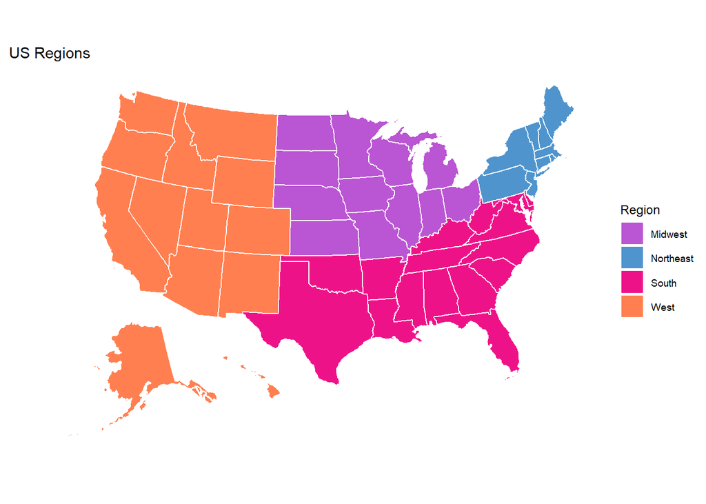

- Question 2: Similar to Question 1, I will build off of the current participation calculations to analyze participation expansion over time. While the `usmap` package was utilized to create the map above, but I do not believe it has coordinate plotting capabilities. Alternatives will be explored but I may change to county plotting if needed for time restraints.
  - Quantitative Methods: Rates of adoption will be calculated for each year and/or time period - potentially as trend lines for general direction and rates of adoption or growth curves for cumulative change.
  - Visual Methods: Faceted maps to show changes in participation over time covering 1985-2024 (likely groups of either 5 or 10 years - e.g., 1985-1994, 1995-2004, 2005-2014, 2015-2024) - may also explore animation if possible. Depending on the final quantitative methods, other visualizations such as line charts, bar plots, or cumulative growth curves may be included to help represent results over time.
  - Variables:
    - `start_date`: will provide years when agencies began reporting to NIBRS
    - `latitude` and `longitude`: will be used for mapping agency locations
      - `county` will be used as an alternative if using `usmap` package
    - `report_status`: variable for determining participation status

## Plan of Attack

Plan of Attack Timeline

| Task Name | Status | Due | Priority | Summary |
| --- | --- | --- | --- | --- |
| Proposal draft | Complete | 06/10/25 | High | Draft proposal with questions, analysis plan, and exploratory analysis/visualization |
| Resolve peer/instructor review | Complete | 06/18/25 | High | Address feedback received during peer/instructor review |
| Data wrangling | In progress | 06/21/25 | Moderate | Prepare data for analysis, finalize required variables |
| Q1 Analysis calculations | In progress | 06/22/25 | Moderate | Calculate participation by area and agency type |
| Q1 Complete visualizations | In progress | 06/24/25 | Moderate | Create plots and summaries by agency type and region |
| Q2 Analysis calculations | To be completed | 06/28/25 | Moderate | Calculate rates of adoption over time |
| Q2 Complete visualizations | To be completed | 06/29/25 | Moderate | Create maps and time-based plots |
| Finalize project and presentation | To be completed | 07/02/25 | High | Complete and polish results summaries and interpretation; finish and record presentation |
| Submit final report | To be completed | 07/02/25 | High | Submit final report, recorded presentation, and website |